# Sommaire

## Décomposition en moyenne mobile pour évaluer la tendance globale

#### Décomposition en moyenne mobile

La moyenne mobile, ou moyenne glissante, est un type de moyenne statistique utilisée pour analyser des séries ordonnées de données, le plus souvent des séries temporelles, en supprimant les fluctuations transitoires de façon à en souligner les tendances à plus long terme. Cette moyenne est dite mobile parce qu'elle est recalculée de façon continue, en utilisant à chaque calcul un sous-ensemble d'éléments dans lequel un nouvel élément remplace le plus ancien ou s'ajoute au sous-ensemble.

Ce type de moyenne est utilisé généralement comme méthode de lissage de valeurs.

```
years  month
2021   3              NaN
       4              NaN
       5        483934.36
       6        484477.01
       7        486685.75
       8        483136.18
       9        490870.21
       10       436867.98
       11       448165.62
       12       454374.50
2022   1        522547.93
       2        529019.18
       3        525545.58
       4        514795.54
       5        508665.89
       6        502172.43
       7        508093.83
       8        504512.08
       9        503884.88
       10       502923.10
       11       499665.65
       12       505023.98
2023   1        508221.58
       2        494879.87
Name: price, dtype: float64
```

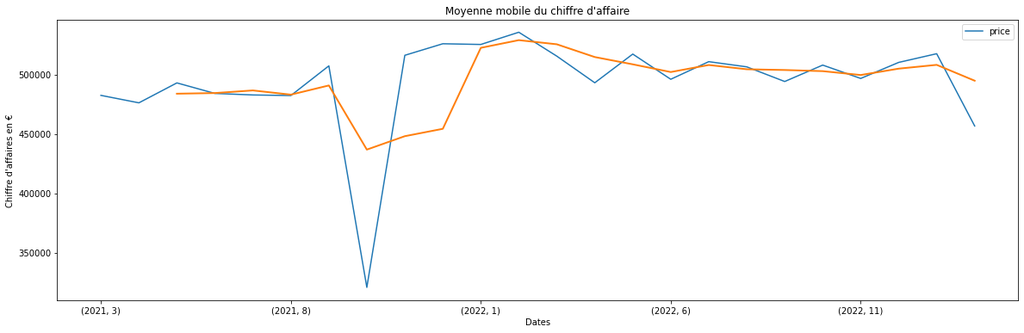

```python
# Decomposition en moyenne mobile:
moyenne_mobile = ca_par_mois.rolling(3).mean()
print(round(moyenne_mobile,2))

#Graphique par mois
plt.figure(figsize = (20,6))
ca_par_mois.plot()
plt.title("Evolution mensuelle du chiffre d'affaires")
plt.legend()

moyenne_mobile.plot(linewidth=2)
plt.xlabel("Dates")
plt.ylabel("Chiffre d'affaires en €")
plt.title("Moyenne mobile du chiffre d'affaire")

plt.savefig("assets/graphiques/7 decomposition en moyenne mobile")
```

```python
achats
```

|  | id_prod | date | session_id | client_id | price | categ | sex | birth | age | years | month | day |
| --- | --- | --- | --- | --- | --- | --- | --- | --- | --- | --- | --- | --- |
| 468405 | 0_1259 | 2021-03-01 00:01:07.843138 | s_1 | c_329 | 11.99 | 0.0 | f | 1967.0 | 55.0 | 2021 | 3 | 1 |
| 497884 | 0_1390 | 2021-03-01 00:02:26.047414 | s_2 | c_664 | 19.37 | 0.0 | m | 1960.0 | 62.0 | 2021 | 3 | 1 |
| 221213 | 0_1352 | 2021-03-01 00:02:38.311413 | s_3 | c_580 | 4.50 | 0.0 | m | 1988.0 | 34.0 | 2021 | 3 | 1 |
| 316014 | 0_1458 | 2021-03-01 00:04:54.559692 | s_4 | c_7912 | 6.55 | 0.0 | f | 1989.0 | 33.0 | 2021 | 3 | 1 |
| 595898 | 0_1358 | 2021-03-01 00:05:18.801198 | s_5 | c_2033 | 16.49 | 0.0 | f | 1956.0 | 66.0 | 2021 | 3 | 1 |
| ... | ... | ... | ... | ... | ... | ... | ... | ... | ... | ... | ... | ... |
| 163305 | 1_508 | 2023-02-28 23:49:03.148402 | s_348444 | c_3573 | 21.92 | 1.0 | f | 1996.0 | 26.0 | 2023 | 2 | 28 |
| 153419 | 2_37 | 2023-02-28 23:51:29.318531 | s_348445 | c_50 | 48.99 | 2.0 | f | 1994.0 | 28.0 | 2023 | 2 | 28 |
| 476829 | 1_695 | 2023-02-28 23:53:18.929676 | s_348446 | c_488 | 26.99 | 1.0 | f | 1985.0 | 37.0 | 2023 | 2 | 28 |
| 428188 | 0_1547 | 2023-02-28 23:58:00.107815 | s_348447 | c_4848 | 8.99 | 0.0 | m | 1953.0 | 69.0 | 2023 | 2 | 28 |
| 398652 | 0_1398 | 2023-02-28 23:58:30.792755 | s_348435 | c_3575 | 4.52 | 0.0 | f | 1981.0 | 41.0 | 2023 | 2 | 28 |

679332 rows × 12 columns

```python
# saisonnalité et tendance
achats.reset_index(inplace=True)
achats['dates'] = pd.to_datetime(achats["date"])
achats = achats.set_index("date")
achats
```

| date | index | id_prod | session_id | client_id | price | categ | sex | birth | age | years | month | day | dates |
| --- | --- | --- | --- | --- | --- | --- | --- | --- | --- | --- | --- | --- | --- |
| 2021-03-01 00:01:07.843138 | 468405 | 0_1259 | s_1 | c_329 | 11.99 | 0.0 | f | 1967.0 | 55.0 | 2021 | 3 | 1 | 2021-03-01 00:01:07.843138 |
| 2021-03-01 00:02:26.047414 | 497884 | 0_1390 | s_2 | c_664 | 19.37 | 0.0 | m | 1960.0 | 62.0 | 2021 | 3 | 1 | 2021-03-01 00:02:26.047414 |
| 2021-03-01 00:02:38.311413 | 221213 | 0_1352 | s_3 | c_580 | 4.50 | 0.0 | m | 1988.0 | 34.0 | 2021 | 3 | 1 | 2021-03-01 00:02:38.311413 |
| 2021-03-01 00:04:54.559692 | 316014 | 0_1458 | s_4 | c_7912 | 6.55 | 0.0 | f | 1989.0 | 33.0 | 2021 | 3 | 1 | 2021-03-01 00:04:54.559692 |
| 2021-03-01 00:05:18.801198 | 595898 | 0_1358 | s_5 | c_2033 | 16.49 | 0.0 | f | 1956.0 | 66.0 | 2021 | 3 | 1 | 2021-03-01 00:05:18.801198 |
| ... | ... | ... | ... | ... | ... | ... | ... | ... | ... | ... | ... | ... | ... |
| 2023-02-28 23:49:03.148402 | 163305 | 1_508 | s_348444 | c_3573 | 21.92 | 1.0 | f | 1996.0 | 26.0 | 2023 | 2 | 28 | 2023-02-28 23:49:03.148402 |
| 2023-02-28 23:51:29.318531 | 153419 | 2_37 | s_348445 | c_50 | 48.99 | 2.0 | f | 1994.0 | 28.0 | 2023 | 2 | 28 | 2023-02-28 23:51:29.318531 |
| 2023-02-28 23:53:18.929676 | 476829 | 1_695 | s_348446 | c_488 | 26.99 | 1.0 | f | 1985.0 | 37.0 | 2023 | 2 | 28 | 2023-02-28 23:53:18.929676 |
| 2023-02-28 23:58:00.107815 | 428188 | 0_1547 | s_348447 | c_4848 | 8.99 | 0.0 | m | 1953.0 | 69.0 | 2023 | 2 | 28 | 2023-02-28 23:58:00.107815 |
| 2023-02-28 23:58:30.792755 | 398652 | 0_1398 | s_348435 | c_3575 | 4.52 | 0.0 | f | 1981.0 | 41.0 | 2023 | 2 | 28 | 2023-02-28 23:58:30.792755 |

679332 rows × 13 columns

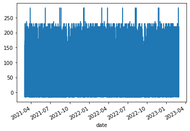

```python
# Saisonnalité des prix
import statsmodels.api as sm
from matplotlib import rcParams
decomposition = sm.tsa.seasonal_decompose(achats["price"],period = 339600)

decomposition.seasonal.plot()
```

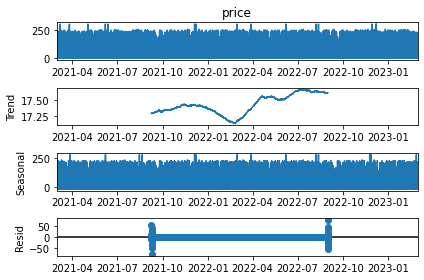

```python
sm.tsa.seasonal_decompose(achats["price"],period=339600).plot()
plt.savefig("assets/graphiques/8.2 saisonnalité.png")
```

[figure not shown]

# Zoom sur les références

```python
reference_achats = achats.groupby(["id_prod"])["session_id"].count()
reference_achats.sort_values()
```

```
id_prod
0_549        1
0_2201       1
2_23         1
0_1284       1
0_1683       1
          ...
1_425     2096
1_498     2128
1_414     2180
1_417     2189
1_369     2252
Name: session_id, Length: 3266, dtype: int64
```

### Les tops

```python
# Les 10 produits les plus vendus
print("la liste des 10 produits les plus vendus : \n",reference_achats.nlargest(10))
```

```
la liste des 10 produits les plus vendus :
 id_prod
1_369    2252
1_417    2189
1_414    2180
1_498    2128
1_425    2096
1_403    1960
1_412    1951
1_413    1945
1_406    1939
1_407    1935
Name: session_id, dtype: int64
```

```python
# Les 10 produits les moins vendus
print("la liste des 10 produits les mois vendus : \n",reference_achats.nsmallest(10))
```

```
la liste des 10 produits les mois vendus :
 id_prod
0_1151    1
0_1284    1
0_1379    1
0_1498    1
0_1539    1
0_1601    1
0_1633    1
0_1683    1
0_1728    1
0_2201    1
Name: session_id, dtype: int64
```

- **Les plus vendus appartiennent à la catégorie 1**
- **Les moins vendus appartiennent à la catégorie 0**

## La répartition par catégorie

```python
# Repartition des references parmis les categories:
repartition_categ = products.groupby(["categ"])["id_prod"].count()
print("Répartitions des références par catégories:\n",repartition_categ)

# Volume de ventes par categories:
prix_categ = products.groupby(["categ"])["price"].mean()
print("Prix moyen d'un livre selon sa catégorie:\n",prix_categ)

# Prix moyen par categories:
prix_categ = products.groupby(["categ"])["price"].mean()
print("Prix moyen d'un livre selon sa catégorie:\n",prix_categ)

# CA par categories:
ca_categ = achats.groupby(achats["categ"])["price"].sum()
print("Chiffre d'affaires par catégorie\n",ca_categ)
```

```
Répartitions des références par catégories:
 categ
0    2308
1     739
2     239
Name: id_prod, dtype: int64
Prix moyen d'un livre selon sa catégorie:
 categ
0     11.732795
1     25.531421
2    108.354686
Name: price, dtype: float64
Prix moyen d'un livre selon sa catégorie:
 categ
0     11.732795
1     25.531421
2    108.354686
Name: price, dtype: float64
Chiffre d'affaires par catégorie
 categ
0.0    4421938.76
1.0    4653722.69
2.0    2780275.02
Name: price, dtype: float64
```

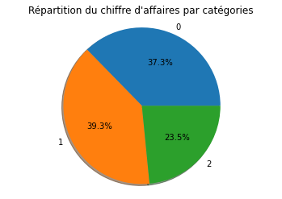

```python
fig1, ax1 = plt.subplots()
ax1.pie(ca_categ,
        labels=["0","1","2"],
        autopct="%1.1f%%",
        shadow=True)
ax1.axis("equal")
plt.title("Répartition du chiffre d'affaires par catégories")
plt.savefig("assets/graphiques/9 Répartition du CA par catégories.png")
plt.show()
```

CCL :

[figure not shown]

# Les profils de nos clients

# Répartition du chiffre d'affaire entre les clients : Courbe de Lorenz et coefficient de Gini :

[reference a voir](https://linuxtut.com/fr/a67ba38e9996db9e976b/)

```python
# Je veux savoir combien chaque client a depensé triée par ordre croissant
achatsClients = df.groupby('client_id')['price'].sum().sort_values().reset_index()
achatsClients
```

|  | client_id | price |
| --- | --- | --- |
| 0 | c_587 | 0.00 |
| 1 | c_4447 | 0.00 |
| 2 | c_7584 | 0.00 |
| 3 | c_4358 | 0.00 |
| 4 | c_6735 | 0.00 |
| ... | ... | ... |
| 8616 | c_3263 | 5276.87 |
| 8617 | c_3454 | 113667.90 |
| 8618 | c_6714 | 153658.86 |
| 8619 | c_4958 | 289760.34 |
| 8620 | c_1609 | 324033.35 |

8621 rows × 2 columns

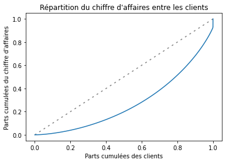

```python
# Répartition du chiffre d'affaires entre les clients
achatsClients = df.groupby('client_id')['price'].sum().sort_values()
n = len(achatsClients)
lorenz = np.cumsum(achatsClients)/ achatsClients.sum()
lorenz = np.append([0],lorenz) # La courbe de Lorenz commence à 0

plt.plot(np.linspace(0,1,len(lorenz)), np.linspace(0,1,len(lorenz)), color ="grey", dashes=[2,4])

xaxis = np.linspace(0-1/n,1+1/n,n+1) #Il y a un segment de taille n pour chaque individu, plus 1 segment supplémentaire d'ordonnée 0. Le premier segment commence à 0-1/n, et le dernier termine à 1+1/n.
plt.plot(xaxis,lorenz,drawstyle='steps-post')
plt.ylabel("Parts cumulées du chiffre d'affaires")
plt.xlabel("Parts cumulées des clients")
plt.title("Répartition du chiffre d'affaires entre les clients")
plt.savefig("assets/graphiques/10 Courbe de Lorenz de la répartition des achats client.png")
plt.show()
```

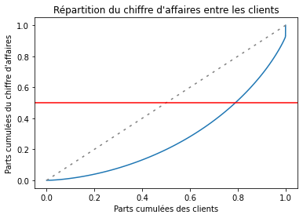

```
La loi de Pareto des 80/20 ou 20/80 s'applique dans ce cas
Maintenant on sait que la somme des achats des acheteurs inférieurs à l'acheteur médial vaut 50 % de la somme de tous les acheteurs, et évidemment, la somme des achats des acheteurs supérieurs à l'acheteur médial vaut 50 % de la somme de tous les acheteurs.
CONCLUSION : Il y a un petit nombre de gros acheteurs
20% des acheteurs font 50% du chiffre d'affaire
 et 80% font 50% du CA
```

```python
#Je veux tracer la médiale : la valeur de la dépance médiale
plt.plot(xaxis,lorenz,drawstyle='steps-post')
plt.title("Répartition du chiffre d'affaires entre les clients")
plt.ylabel("Parts cumulées du chiffre d'affaires")
plt.xlabel("Parts cumulées des clients")
plt.plot(np.linspace(0,1,len(lorenz)), np.linspace(0,1,len(lorenz)),color ="grey", dashes=[2,4])
plt.axhline(0.5, color='red')
plt.savefig("assets/graphiques/10 Courbe de Lorenz Médiale et 80-20.png")
plt.show()
print("La loi de Pareto des 80/20 ou 20/80 s'applique dans ce cas")
print("Maintenant on sait que la somme des achats des acheteurs inférieurs à l'acheteur médial vaut 50 % de la somme de tous les acheteurs, et évidemment, la somme des achats des acheteurs supérieurs à l'acheteur médial vaut 50 % de la somme de tous les acheteurs.\nCONCLUSION : Il y a un petit nombre de gros acheteurs\n20% des acheteurs font 50% du chiffre d'affaire \n et 80% font 50% du CA")
```

# Indice de gini

```python
AUC = (lorenz.sum() -lorenz[-1]/2 -lorenz[0]/2)/n # Surface sous la courbe de Lorenz. Le premier segment (lorenz[0]) est à moitié en dessous de 0, on le coupe donc en 2, on fait de même pour le dernier segment lorenz[-1] qui est à moitié au dessus de 1.
S = 0.5 - AUC # surface entre la première bissectrice et le courbe de Lorenz
gini = 2*S
print("L'indice de Gini : ",gini,"montre la répartition des acheteurs est hétéroclite : qui peut s'expliquer par différentes hypothèses, les types d'acheteurs (occasionnels, professionnels, passionées... dans tous les cas il s'éloigne fortement de 0 donc le poids des produits dans le chiffre d'affaire est très inégal")
```

[output not shown]

```python
meilleurs_clients = achats.groupby(["client_id"])["price"].sum()
```

- la répartition des acheteurs est hétéroclite : qui peut s'expliquer par différentes hypothèses, les types d'acheteurs (occasionnels, professionnels (libraires, bibliotécaires, revendeurs...), passionées...
- dans tous les cas il s'éloigne fortement de 0 donc le poids des produits dans le chiffre d'affaire est très inégal

```python
# meilleurs clients
meilleurs_clients = achats.groupby(["client_id"])["price"].sum()
meilleurs_clients.nlargest(10)
```

```
client_id
c_1609    324033.35
c_4958    289760.34
c_6714    153658.86
c_3454    113667.90
c_3263      5276.87
c_1570      5271.62
c_2899      5214.05
c_2140      5208.82
c_7319      5155.77
c_8026      5092.57
Name: price, dtype: float64
```

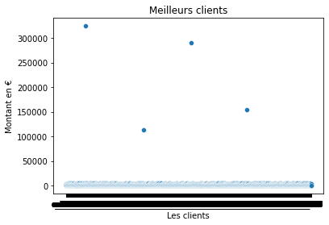

```python
# Graphique:
sns.scatterplot(data= meilleurs_clients)
plt.ylabel("Montant en €")
plt.xlabel("Les clients")
plt.title("Meilleurs clients")
```

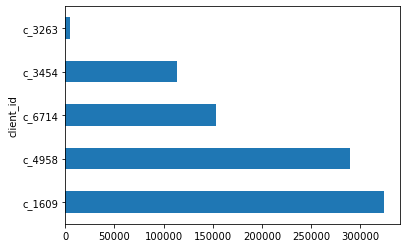

```python
# Mise en avant des 4 meilleurs clients
meilleurs_clients.nlargest(5).plot(kind="barh")
plt.savefig("assets/graphiques/16 meilleurs clients")
```

```python
# Apport des gros clients au Chiffre d'affaire
print("Les meilleurs clients représentent :",round(meilleurs_clients.nlargest(4).sum()/CA*100,2),"% du Chiffre d'affaire total")
```

```
Les meilleurs clients représentent : 7.43 % du Chiffre d'affaire total
```

```python
# nombre d'achats par client
nb_achat_moyen = achats.groupby(["client_id"])["session_id"].count().mean()
print("Le nombre moyen d'achats par client : ",nb_achat_moyen)
```

```
Le nombre moyen d'achats par client :  78.99209302325582
```

```python
# montant moyen par client
montant_achats_moyen = achats.groupby(['client_id'])["price"].sum().mean()
print("Le montant moyen par client : ",montant_achats_moyen)
```

```
Le montant moyen par client :  1378.597263953488
```

```python
# DF sans les 4 gros clients
df_sgc= df
df_sgc.drop(df_sgc.loc[df_sgc['client_id']=='c_1609'].index, inplace=True)
df_sgc.drop(df_sgc.loc[df_sgc['client_id']=='c_3454'].index, inplace=True)
df_sgc.drop(df_sgc.loc[df_sgc['client_id']=='c_4958'].index, inplace=True)
df_sgc.drop(df_sgc.loc[df_sgc['client_id']=='c_6714'].index, inplace=True)
```

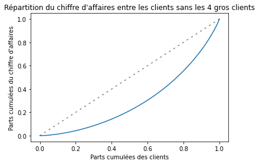

```python
# Répartition du CA entre les clients sans les 4 gros clients (df_sgc)
achatsClients = df_sgc.groupby('client_id')['price'].sum().sort_values()
n = len(achatsClients)
lorenz = np.cumsum(achatsClients)/ achatsClients.sum()
lorenz = np.append([0],lorenz) # La courbe de Lorenz commence à 0

plt.plot(np.linspace(0,1,len(lorenz)), np.linspace(0,1,len(lorenz)), color ="grey", dashes=[2,4])

xaxis = np.linspace(0-1/n,1+1/n,n+1) #Il y a un segment de taille n pour chaque individu, plus 1 segment supplémentaire d'ordonnée 0. Le premier segment commence à 0-1/n, et le dernier termine à 1+1/n.
plt.plot(xaxis,lorenz,drawstyle='steps-post')
plt.ylabel("Parts cumulées du chiffre d'affaires")
plt.xlabel("Parts cumulées des clients")
plt.title("Répartition du chiffre d'affaires entre les clients sans les 4 gros clients")
plt.savefig("assets/graphiques/10.2 Courbe de Lorenz de la répartition des achats client sans les 4 gros clients.png")
plt.show()
```

```python
AUC = (lorenz.sum() -lorenz[-1]/2 -lorenz[0]/2)/n # Surface sous la courbe de Lorenz. Le premier segment (lorenz[0]) est à moitié en dessous de 0, on le coupe donc en 2, on fait de même pour le dernier segment lorenz[-1] qui est à moitié au dessus de 1.
S = 0.5 - AUC # surface entre la première bissectrice et le courbe de Lorenz
gini = 2*S
print("L'indice de Gini : ",gini)
```

```
L'indice de Gini :  0.4040857644394076
```

# Répartition du Chiffre d'affaire entre les produits : Courbe de Lorenz

```
indice de Gini: 0.694
```

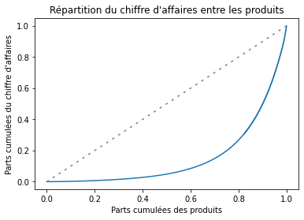

```python
# Courbe de Lorentz: (Repartition du CA par produits)
nbr_ventes_ref = achats.groupby(["id_prod"])["session_id"].count()
lorenz_CA_prod = np.cumsum(np.sort(nbr_ventes_ref)) / nbr_ventes_ref.sum()
lorenz_CA_prod = np.append([0], lorenz_CA_prod)
plt.plot(np.linspace(0,1,len(lorenz_CA_prod)), lorenz_CA_prod, drawstyle='steps-post'),
plt.plot(np.linspace(0,1,len(lorenz_CA_prod)), np.linspace(0,1,len(lorenz_CA_prod)),color ="grey", dashes=[2,4])
plt.ylabel("Parts cumulées du chiffre d'affaires")
plt.xlabel("Parts cumulées des produits")
plt.title("Répartition du chiffre d'affaires entre les produits")
plt.savefig("assets/graphiques/10 Courbe de Lorenz produits.png")

aire_ss_courbe_CA_prod = lorenz_CA_prod[:-1].sum() / len(lorenz_CA_prod)
S_ca_prod = 0.5 - aire_ss_courbe_CA_prod
gini_CA_prod = 2* S_ca_prod
print("indice de Gini:",round(gini_CA_prod,3))
```

```python
print("L'indice de Gini est loin de 0 le poids des produits dans le chiffre d'affaires total est donc très inégal.")
print("Loi des 80/20 : 20 % des produits fournissent 80% du Chiffre d'affaires")
```

[output not shown]

[figure not shown]

## Répartition par sexe des clients

[figure not shown]

```python
#Répartition du nombre d'achats en fonction du genre du client
achats['sex'].value_counts(normalize=False).plot(kind='pie',rot='0',
                                                 labels=["Femmes","Homme"],
                                                 autopct="%1.1f%%")
plt.xlabel("")
plt.ylabel("")
plt.title("Nombre de ventes par genre")
plt.savefig("assets/graphiques/9.2 Nombre de vente par genre.png")
plt.show()
```

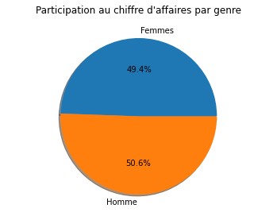

```python
repartition_achats_sexe = achats.groupby(["sex"])["price"].sum()
plt.figure()
fig, ax = plt.subplots()
ax.pie(repartition_achats_sexe,
        labels=["Femmes","Homme"],
        autopct="%1.1f%%",
        shadow=True)
ax.axis("equal")
plt.title("Participation au chiffre d'affaires par genre\n")
plt.savefig("assets/graphiques/ 12 Partitcipation au CA par genre.png")
plt.show()
```

```python
# Dépense par genres:
repartition_achats_genre = achats.groupby(['sex'])['price'].sum()
print(f"Montant total des achats par genre en euros:\n{repartition_achats_genre}")

print("__________________________________________________")
# Nombre d'achats par genre
nb_achats_genre = achats.groupby(["sex"])["price"].count()
print(f"Nombre total d'achats par genre\n {nb_achats_genre}")
print("__________________________________________________")

# moyenne des dépenses par genre
mean_achats_genre = achats.groupby(["sex"])["price"].mean()
print(f"Moyenne des achats par genre\n {mean_achats_genre}")
```

```
Montant total des achats par genre en euros:
sex
f    5860851.96
m    5995084.51
Name: price, dtype: float64
__________________________________________________
Nombre total d'achats par genre
 sex
f    338402
m    340930
Name: price, dtype: int64
__________________________________________________
Moyenne des achats par genre
 sex
f    17.319200
m    17.584503
Name: price, dtype: float64
```

[figure not shown]

## le lien entre le genre d’un client et les catégories des livres achetés